# DigiKat Map 4: Temporal Dynamics

Mapping the Evolution of Croatian Catholic Digital Communication

Author

DigiKat Project

Published

January 27, 2026

# 1 Introduction

This document presents **Map 4 of the DigiKat project**, analyzing the temporal dynamics of Croatian Catholic digital media. The core question driving this analysis is **How does Croatian Catholic digital communication evolve over time, and how does it respond to events?**

## 1.1 Methodological Overview

**Temporal analysis** examines how communication patterns change across multiple time scales. This includes macro trends (yearly, monthly), meso patterns (weekly, liturgical seasons), and micro rhythms (daily, hourly).

**Key metrics in this analysis:**

| Metric | Definition | Interpretation |
| --- | --- | --- |
| Rolling average | Smoothed trend over N days | Removes noise to reveal underlying patterns |
| Year over Year (YoY) | Current vs same period last year | Shows growth or decline trajectory |
| CAGR | Compound Annual Growth Rate | Standardized multi year growth measure |
| Effect size | (Event period - Baseline) / Baseline | Quantifies impact of events or seasons |
| Sunday Index | Sunday activity / Weekday average | Measures distinctive Sunday patterns |

**Interpretation guidance:**

- Rising rolling averages indicate growth; declining suggests contraction
- Positive YoY change shows expansion; negative indicates decline
- Effect sizes above 0% show increased activity during events/seasons
- Sunday Index above 1.0 indicates higher Sunday activity than weekday average
- Platform correlations reveal synchronized vs independent communication patterns

**Liturgical calendar mapping:**

The Catholic liturgical year structures religious communication. Key seasons include Advent (preparation for Christmas), Christmas (Dec 25 to Epiphany), Lent (40 days before Easter), Easter (50 days to Pentecost), and Ordinary Time (remainder). Feast days create additional activity spikes.

```r
dta <- readRDS("C:/Users/lsikic/Luka C/HKS/Projekti/Digitalni Kat/SHKM/DigiKat/data/merged_comprehensive.rds") %>%
  filter(SOURCE_TYPE != "tiktok", !is.na(SOURCE_TYPE)) %>%
  filter(DATE >= as.Date("2021-01-01") & DATE <= as.Date("2025-12-31")) %>%
  filter(year >= 2021 & year <= 2025)

setDT(dta)

cat("Data loaded:", nrow(dta), "rows\n")
```

```
Data loaded: 608879 rows
```

```r
if (nrow(dta) == 0) stop("No data after filtering! Check your date filters.")

dta[, DATE := as.Date(DATE)]
dta[, Year := year(DATE)]
dta[, Month := month(DATE)]
dta[, Week := isoweek(DATE)]
dta[, DOW := lubridate::wday(DATE, label = TRUE, abbr = FALSE)]
dta[, DOW_num := lubridate::wday(DATE)]
dta[, Hour := as.integer(substr(TIME, 1, 2))]

n_posts <- nrow(dta)
n_sources <- uniqueN(dta$FROM)
date_range <- paste(min(dta$DATE, na.rm = TRUE), "to", max(dta$DATE, na.rm = TRUE))
```

```r
# =============================================================================
# ACTOR CLASSIFICATION V4 - SYNCHRONIZED WITH MAPS 1, 2, 3
# =============================================================================
# Uses hierarchical priority: manual overrides -> secular exclusions ->
# domain matching -> pattern matching -> lay influencer detection -> default
# =============================================================================

# MANUAL OVERRIDES: Highest priority explicit classifications
manual_overrides <- list(
  "Institutional Official" = c(
    "hrvatska katolička mreža", "hrvatska katolicka mreza",
    "informativna katolička agencija", "informativna katolicka agencija",
    "hrvatski katolički radio", "hrvatski katolicki radio",
    "hrvatska biskupska konferencija", "ika", "hkr", "hkm", "hbk",
    "tiskovni ured hbk", "radio marija"
  ),
  "Independent Media" = c(
    "laudato tv", "laudatotv", "laudato.tv", "laudato.hr", "laudato",
    "bitno.net", "bitno net", "glas koncila", "glaskoncila",
    "nova eva", "nova-eva", "verbum", "totus tuus", "totus-tuus",
    "katolički tjednik", "katolicki tjednik", "kršćanska sadašnjost",
    "krscanska sadasnjost", "mir i dobro", "svjetlo riječi",
    "novizivot.net", "novi zivot", "novi život"
  ),
  "Charismatic Communities" = c(
    "božja pobjeda", "bozja pobjeda", "bozjapobjeda",
    "muževni budite", "muzevni budite", "muzevnibudite",
    "srce isusovo", "srceisuovo", "cenacolo", "comunità cenacolo",
    "duhovna obnova", "molitvena snaga",
    "dom molitve slavonski brod", "dom molitve",
    "molitvena zajednica sv. josipa"
  ),
  "Lay Influencers" = c(
    "katolička obitelj", "katolicka obitelj",
    "marija majka isusova", "božanske molitve", "bozanske molitve",
    "moćne molitve tv", "mocne molitve tv", "moćne molitve", "mocne molitve",
    "katoličke molitve", "katolicke molitve",
    "pulherissimus", "pod smokvom",
    "hrana za dušu", "hrana za dusu",
    "добровољци", "miletić marin", "miletic marin",
    "dijete vjere", "vjera",
    "kapljice ljubavi božje", "kapljice ljubavi bozje",
    "kršćanstvo", "krscanstvo",
    "jutarnja molitva duhu svetom", "blago molitve",
    "biblija krunice molitve",
    "molitve bogu",
    "vojnik sreće", "vojnik srece", "duhovne poruke i inspiracija",
    "kes duhovni kutak", "duhovni kutak",
    "molitve.hr", "duhovniportal.com", "duhovniportal"
  ),
  "Diocesan" = c(
    "zagrebačka nadbiskupija", "zagrebacka nadbiskupija",
    "sisačka biskupija", "sisacka biskupija",
    "župa šurkovac", "zupa surkovac", "sveta mati slobode",
    "župa sv. ilije proroka metković", "zupa sv. ilije proroka metkovic",
    "župa uznesenja bdm", "zupa uznesenja bdm", "župa uznesenja bdm - stenjevec",
    "šibenska biskupija", "sibenska biskupija",
    "požeška biskupija", "pozeskа biskupija",
    "dubrovacka biskupija", "dubrovačka biskupija",
    "dubrovacka-biskupija.hr",
    "zupa tramosnica", "župa tramošnica",
    "župa sv. vida", "zupa sv. vida", "župa sv. vida - petruševec"
  ),
  "Youth Organizations" = c(
    "susret hrvatske katoličke mladeži", "susret hrvatske katolicke mladezi",
    "shkm požega", "shkm pozega"
  ),
  "Academic" = c(
    "hrvatsko katoličko sveučilište", "hrvatsko katolicko sveuciliste",
    "universitas studiorum catholica croatica"
  )
)

# SECULAR MEDIA EXCLUSIONS: Always classify as Other
secular_exclusions <- c(
  # National portals
  "slobodnadalmacija", "slobodnadalmacija.hr",
  "vecernji", "vecernji.hr",
  "index.hr", "index",
  "jutarnji", "jutarnji.hr",
  "novilist", "novilist.hr",
  "24sata", "24sata.hr",
  "direktno", "direktno.hr",
  "nacional", "nacional.hr",
  "tportal", "tportal.hr",
  "dnevnik.hr", "dnevnik",
  "hrt.hr", "hrt",
  "n1info", "n1info.hr", "n1",
  "rtl.hr", "rtl",
  "net.hr",
  "telegram.hr", "telegram",
  "story.hr", "express.hr", "express", "advance.hr",
  # Regional portals
  "glasistre", "glasistre.hr",
  "dnevno.hr", "dnevno",
  "prigorski", "glas-slavonije", "glas slavonije",
  "croativ", "oluja.info",
  "maxportal", "maxportal.hr",
  "hkv.hr", "icv.hr", "novosti.hr", "7dnevno", "mnovine",
  "sjever.hr", "dulist.hr", "pozega.eu", "sibenik.in",
  "ferata.hr", "epodravina", "glasgacke", "radio-zlatar",
  "medjimurski.hr", "sbperiskop", "zagorje-international",
  "pozeski", "novine.hr", "dubrovnikinsider", "regionalni",
  "leportale", "varazdinske-vijesti", "radionasice",
  "brodportal", "ljportal", "dubrovnikportal", "01portal",
  "tomislavnews", "hia.com.hr", "portalnovosti", "antenazadar",
  "dalmacijanews", "zadarskilist", "medjimurjepress",
  "zagreb.info", "034portal", "057info", "cityportal",
  "klikaj.hr", "lika-online", "ploce.com", "sbonline",
  "narod.hr", "infokiosk", "hrsvijet", "tomislavcity",
  "vrisak.info", "dalmacijadanas", "dalmacijadanas.hr",
  "morski.hr", "zagreb.hr", "osijek031", "rijeka.hr", "zadar.hr",
  "zupanjac.net", "zupanjac",
  "dalmatinskiportal.hr", "dalmatinskiportal",
  "campaign-archive.com",
  # Forums and aggregators
  "forum.hr", "reddit", "anonymous_user", "komentari", "bug.hr",
  # Entertainment and other
  "inmemoriam", "magicus.info", "book.hr", "mojzagreb.info",
  "skole.hr", "tvprofil", "priznajem.hr", "dragovoljac.com",
  "croatia", "wikipedia",
  "facebook.com", "youtube.com", "instagram.com", "twitter.com",
  # Government and administrative
  "županija", "zupanija", "grad ", "opcina", "općina",
  # Non-Catholic religious groups
  "kršćanska proročka crkva", "krscanska prorocka crkva",
  "crkva svemogućeg boga", "crkva svemoguceg boga",
  "jehovini svjedoci", "adventisti", "baptisti", "pentekostalna",
  # Political parties
  "domovinski pokret", "hdz", "sdp", "most", "možemo", "mozemo"
)

classify_actor_v4 <- function(from_value, url_value = NA, platform_value = NA) {
  from_lower <- tolower(from_value)
  url_lower <- tolower(ifelse(is.na(url_value), "", url_value))
  platform_lower <- tolower(ifelse(is.na(platform_value), "", platform_value))
  combined <- paste(from_lower, url_lower)

  match_any <- function(patterns, text) {
    any(sapply(patterns, function(p) grepl(p, text, fixed = TRUE)))
  }

  # PRIORITY 1: Manual overrides
  for (actor_type in names(manual_overrides)) {
    if (match_any(manual_overrides[[actor_type]], from_lower)) {
      return(actor_type)
    }
  }

  # PRIORITY 2: Secular exclusions
  if (match_any(secular_exclusions, combined)) {
    return("Other")
  }

  # PRIORITY 3: Domain-based classification
  institutional_domains <- c("hkm.hr", "ika.hkm.hr", "hkr.hkm.hr", "hbk.hr")
  if (any(sapply(institutional_domains, function(x) grepl(x, url_lower, fixed = TRUE)))) {
    return("Institutional Official")
  }

  diocesan_domains <- c(
    "zg-nadbiskupija.hr", "biskupija-varazdinska.hr", "djos.hr",
    "biskupija-sj.hr", "rzs.hr", "rkc-sisak.hr", "zadarskanadbiskupija.hr",
    "gospicko-senjska-biskupija.hr", "nadbiskupija-split.com",
    "dubrovacka-biskupija.hr", "porec-biskupija.hr", "biskupija-kk.hr"
  )
  if (any(sapply(diocesan_domains, function(x) grepl(x, url_lower, fixed = TRUE)))) {
    return("Diocesan")
  }

  independent_media_domains <- c(
    "laudato.hr", "laudato.tv", "bitno.net", "glaskoncila.hr",
    "nova-eva.com", "verbum.hr", "ks.hr", "novizivot.net"
  )
  if (any(sapply(independent_media_domains, function(x) grepl(x, url_lower, fixed = TRUE)))) {
    return("Independent Media")
  }

  # PRIORITY 4: Pattern-based classification
  is_parish <- grepl("^župa|^zupa|župi|zupi|- župa|- zupa", from_lower, ignore.case = TRUE) ||
               grepl("parish", from_lower, ignore.case = TRUE)

  diocesan_names <- c("nadbiskupija", "biskupija")
  if (is_parish || any(sapply(diocesan_names, function(x) grepl(x, from_lower, fixed = TRUE)))) {
    return("Diocesan")
  }

  religious_orders <- c(
    "franjevci", "franjevački", "franjevacki", "ofm",
    "isusovci", "družba isusova", "druzba isusova",
    "dominikanci", "dominikanski",
    "salezijanci", "salezijanski", "sdb",
    "karmelićani", "karmelicani", "karmel",
    "benediktinci", "benediktinski", "osb",
    "kapucini", "kapucinski", "ofmcap",
    "pavlini", "pavlinski", "trapisti", "cisterciti",
    "sestre milosrdnice", "uršulinke", "klarise",
    "službenice milosrđa", "kćeri božje ljubavi", "kceri bozje ljubavi"
  )
  if (any(sapply(religious_orders, function(x) grepl(x, from_lower, fixed = TRUE)))) {
    return("Religious Orders")
  }

  charismatic <- c(
    "molitvena zajednica", "karizmatska", "cenacolo",
    "emmanuel community", "emmanuel zajednica", "taize",
    "neokatekumenski", "neokatekumenska", "kursiljo",
    "fokolari", "fokolarini", "komunija i oslobođenje",
    "dom molitve", "kuća molitve", "kuca molitve"
  )
  if (any(sapply(charismatic, function(x) grepl(x, from_lower, fixed = TRUE)))) {
    return("Charismatic Communities")
  }

  priest_prefixes <- c("fra ", "don ", "vlč.", "vlc.", "msgr.", "mons.",
                       "o. ", "pater ", "preč.", "prec.")
  for (prefix in priest_prefixes) {
    if (startsWith(from_lower, prefix)) return("Individual Priests")
  }
  if (grepl("svećenik|svecenik|župnik|zupnik", from_lower)) {
    return("Individual Priests")
  }

  youth <- c(
    "frama", "shkm", "katolička mladež", "katolicka mladez",
    "ministranti", "mladifra", "mladi fra", "kaem",
    "sveučilišna kapelanija", "studentska kapelanija"
  )
  if (any(sapply(youth, function(x) grepl(x, from_lower, fixed = TRUE)))) {
    return("Youth Organizations")
  }

  academic <- c(
    "unicath", "katolički bogoslovni fakultet", "kbf",
    "teologija", "filozofski fakultet družbe isusove", "hks.hr",
    "hrvatsko katoličko sveučilište", "hku"
  )
  if (any(sapply(academic, function(x) grepl(x, from_lower, fixed = TRUE)))) {
    return("Academic")
  }

  # PRIORITY 5: Lay influencer detection (platform-aware)
  lay_keywords <- c(
    "vjera", "molitva", "molitve", "isus", "krist", "gospa", "marija",
    "duhovnost", "duhovna", "duhovni", "biblija", "psalm", "blagoslov",
    "krunica", "rozarij", "katolička obitelj", "evanđelje", "evandelje"
  )

  lay_exclude <- c(".hr", ".net", ".com", "portal", "vijesti", "news", "radio")

  is_likely_social <- platform_lower %in% c("facebook", "instagram", "youtube", "twitter") ||
                      !grepl("\\.[a-z]{2,4}$", from_lower)

  has_devotional <- any(sapply(lay_keywords, function(x) grepl(x, from_lower, fixed = TRUE)))
  has_media_marker <- any(sapply(lay_exclude, function(x) grepl(x, from_lower, fixed = TRUE)))

  if (is_likely_social && has_devotional && !has_media_marker) {
    return("Lay Influencers")
  }

  return("Other")
}

# Apply classification
dta[, ACTOR_TYPE := mapply(classify_actor_v4, FROM, URL, SOURCE_TYPE)]

cat("ACTOR_TYPE class:", class(dta$ACTOR_TYPE), "\n")
```

```
ACTOR_TYPE class: character
```

```r
cat("ACTOR_TYPE distribution:\n")
```

```
ACTOR_TYPE distribution:
```

```r
print(table(dta$ACTOR_TYPE))
```

```
               Academic Charismatic Communities                Diocesan
                    671                    1282                   13841
      Independent Media  Institutional Official         Lay Influencers
                  31401                   62744                   28451
                  Other        Religious Orders     Youth Organizations
                 468760                    1677                      52
```

## 1.2 Corpus Overview

```r
tibble(
  Metric = c("Total posts", "Unique sources", "Date range", "Platforms",
             "Years covered", "Posts with timestamp"),
  Value = c(
    format(n_posts, big.mark = ","),
    format(n_sources, big.mark = ","),
    date_range,
    paste(unique(dta$SOURCE_TYPE), collapse = ", "),
    paste(sort(unique(dta$Year)), collapse = ", "),
    format(sum(!is.na(dta$Hour)), big.mark = ",")
  )
) %>%
  kable(col.names = c("Metric", "Value")) %>%
  kable_styling(bootstrap_options = c("striped", "hover"), full_width = FALSE)
```

| Metric | Value |
| --- | --- |
| Total posts | 608,879 |
| Unique sources | 16,426 |
| Date range | 2021-01-01 to 2025-12-31 |
| Platforms | web, facebook, twitter, comment, youtube, forum, reddit, instagram |
| Years covered | 2021, 2022, 2023, 2024, 2025 |
| Posts with timestamp | 608,879 |

# 2 Analysis 4.1: Overall Temporal Patterns

The first analysis examines macro level trends in posting volume and engagement over the corpus period. This reveals overall growth or decline patterns and identifies major activity peaks.

**Reading the charts:**

- **Daily volume** shows raw activity with smoothing to reveal trends
- **7 day rolling average** captures weekly patterns while reducing noise
- **30 day rolling average** shows monthly trend direction
- **YoY change** indicates whether activity is growing or declining relative to prior year

```r
daily_stats <- dta[, .(
  Posts = .N,
  Total_Interactions = sum(INTERACTIONS, na.rm = TRUE),
  Mean_Interactions = mean(INTERACTIONS, na.rm = TRUE),
  Unique_Sources = uniqueN(FROM)
), by = DATE][order(DATE)]

daily_stats[, Rolling_Posts_7d := frollmean(Posts, 7, align = "right")]
daily_stats[, Rolling_Posts_30d := frollmean(Posts, 30, align = "right")]
daily_stats[, Rolling_Interactions_7d := frollmean(Total_Interactions, 7, align = "right")]
```

## 2.1 Daily Posting Volume

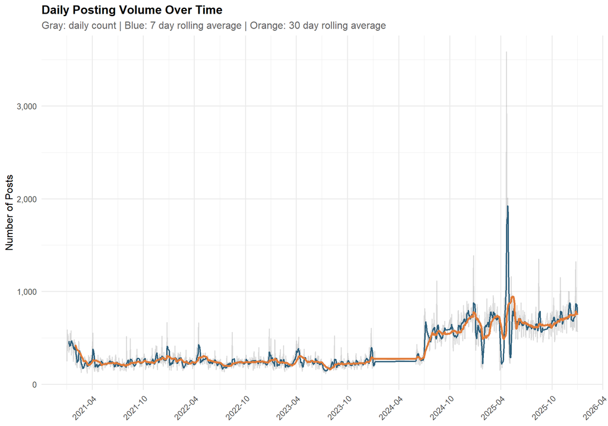

```r
ggplot(daily_stats[!is.na(DATE)], aes(x = DATE)) +
  geom_line(aes(y = Posts), alpha = 0.3, color = "gray50") +
  geom_line(aes(y = Rolling_Posts_7d), color = "#2c5f7c", linewidth = 0.8) +
  geom_line(aes(y = Rolling_Posts_30d), color = "#e07b39", linewidth = 1.2) +
  scale_x_date(date_labels = "%Y-%m", date_breaks = "6 months") +
  scale_y_continuous(labels = comma) +
  labs(
    title = "Daily Posting Volume Over Time",
    subtitle = "Gray: daily count | Blue: 7 day rolling average | Orange: 30 day rolling average",
    x = NULL,
    y = "Number of Posts"
  ) +
  theme(axis.text.x = element_text(angle = 45, hjust = 1))
```

## 2.2 Monthly Aggregated Trends

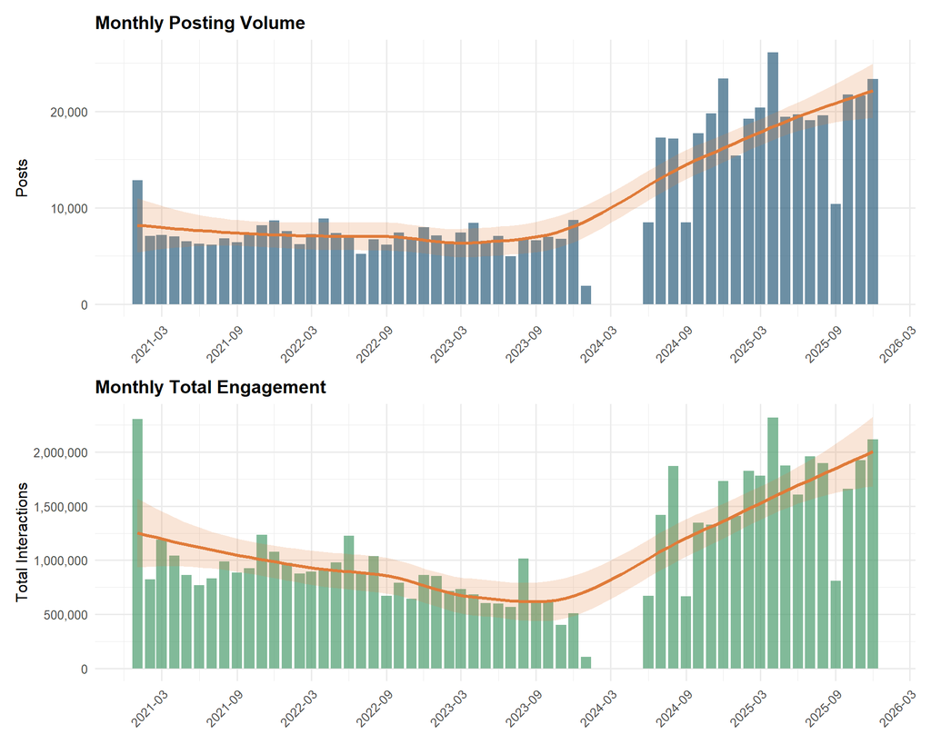

```r
monthly_stats <- dta[, .(
  Posts = .N,
  Total_Interactions = sum(INTERACTIONS, na.rm = TRUE),
  Mean_Interactions = mean(INTERACTIONS, na.rm = TRUE),
  Unique_Sources = uniqueN(FROM)
), by = .(Year, Month)]

monthly_stats[, Date := as.Date(paste(Year, Month, "01", sep = "-"))]
monthly_stats <- monthly_stats[order(Date)]

p1 <- ggplot(monthly_stats[!is.na(Date)], aes(x = Date, y = Posts)) +
  geom_col(fill = "#2c5f7c", alpha = 0.7) +
  geom_smooth(method = "loess", se = TRUE, color = "#e07b39", fill = "#e07b39", alpha = 0.2) +
  scale_x_date(date_labels = "%Y-%m", date_breaks = "6 months") +
  scale_y_continuous(labels = comma) +
  labs(
    title = "Monthly Posting Volume",
    x = NULL,
    y = "Posts"
  ) +
  theme(axis.text.x = element_text(angle = 45, hjust = 1))

p2 <- ggplot(monthly_stats[!is.na(Date)], aes(x = Date, y = Total_Interactions)) +
  geom_col(fill = "#4a9c6d", alpha = 0.7) +
  geom_smooth(method = "loess", se = TRUE, color = "#e07b39", fill = "#e07b39", alpha = 0.2) +
  scale_x_date(date_labels = "%Y-%m", date_breaks = "6 months") +
  scale_y_continuous(labels = comma) +
  labs(
    title = "Monthly Total Engagement",
    x = NULL,
    y = "Total Interactions"
  ) +
  theme(axis.text.x = element_text(angle = 45, hjust = 1))

p1 / p2
```

## 2.3 Year over Year Comparison

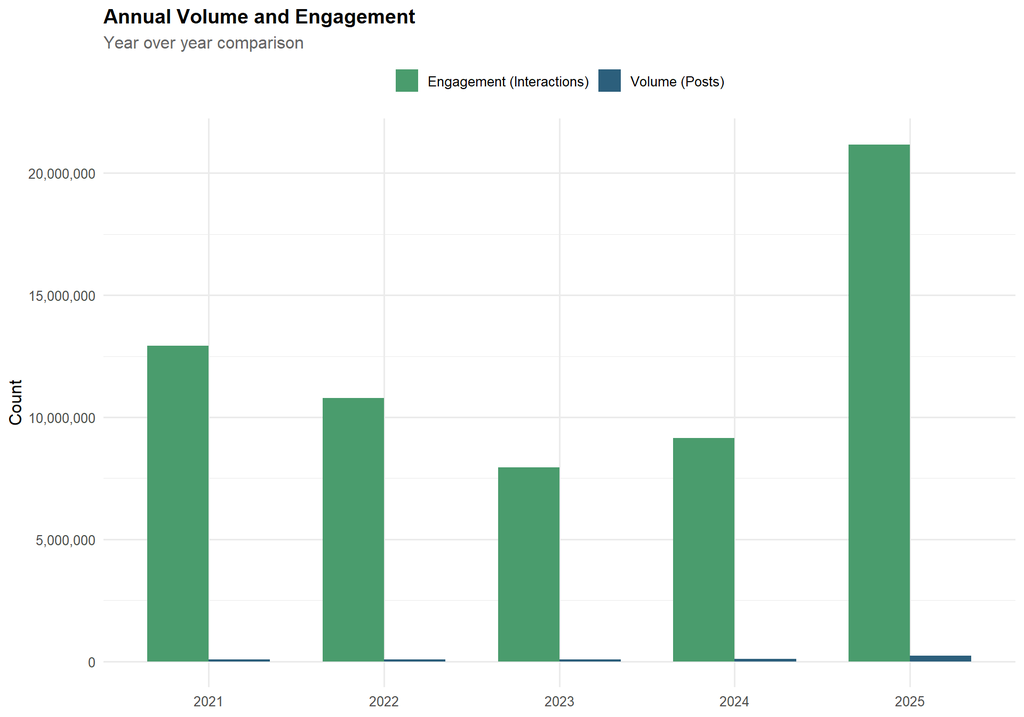

```r
yearly_stats <- dta[, .(
  Posts = .N,
  Total_Interactions = sum(INTERACTIONS, na.rm = TRUE),
  Mean_Interactions = mean(INTERACTIONS, na.rm = TRUE),
  Unique_Sources = uniqueN(FROM)
), by = Year][order(Year)]

yearly_stats[, Posts_Change := (Posts - shift(Posts)) / shift(Posts) * 100]
yearly_stats[, Interactions_Change := (Total_Interactions - shift(Total_Interactions)) / shift(Total_Interactions) * 100]

yearly_long <- yearly_stats %>%
  select(Year, Posts, Total_Interactions) %>%
  pivot_longer(cols = -Year, names_to = "Metric", values_to = "Value") %>%
  mutate(Metric = ifelse(Metric == "Posts", "Volume (Posts)", "Engagement (Interactions)"))

ggplot(yearly_long, aes(x = factor(Year), y = Value, fill = Metric)) +
  geom_col(position = "dodge", width = 0.7) +
  scale_fill_manual(values = c("Volume (Posts)" = "#2c5f7c", "Engagement (Interactions)" = "#4a9c6d")) +
  scale_y_continuous(labels = comma) +
  labs(
    title = "Annual Volume and Engagement",
    subtitle = "Year over year comparison",
    x = NULL,
    y = "Count",
    fill = NULL
  ) +
  theme(legend.position = "top")
```

## 2.4 Yearly Statistics Table

```r
yearly_stats %>%
  mutate(
    Posts = format(Posts, big.mark = ","),
    Total_Interactions = format(Total_Interactions, big.mark = ","),
    Mean_Interactions = sprintf("%.1f", Mean_Interactions),
    Unique_Sources = format(Unique_Sources, big.mark = ","),
    Posts_Change = ifelse(is.na(Posts_Change), "—", sprintf("%+.1f%%", Posts_Change)),
    Interactions_Change = ifelse(is.na(Interactions_Change), "—", sprintf("%+.1f%%", Interactions_Change))
  ) %>%
  select(Year, Posts, Posts_Change, Total_Interactions, Interactions_Change,
         Mean_Interactions, Unique_Sources) %>%
  kable(col.names = c("Year", "Posts", "YoY Change", "Interactions", "YoY Change",
                      "Mean Int.", "Sources")) %>%
  kable_styling(bootstrap_options = c("striped", "hover"), full_width = FALSE)
```

| Year | Posts | YoY Change | Interactions | YoY Change | Mean Int. | Sources |
| --- | --- | --- | --- | --- | --- | --- |
| 2021 | 90,388 | — | 12,936,397 | — | 149.2 | 2,830 |
| 2022 | 84,535 | -6.5% | 10,779,254 | -16.7% | 131.6 | 3,137 |
| 2023 | 83,834 | -0.8% | 7,943,765 | -26.3% | 97.2 | 2,749 |
| 2024 | 114,187 | +36.2% | 9,139,533 | +15.1% | 82.1 | 6,088 |
| 2025 | 235,935 | +106.6% | 21,171,395 | +131.6% | 92.7 | 10,146 |

## 2.5 Peak Activity Days

**Click to expand** (Top 20 highest volume days)**

```r
top_days <- daily_stats[order(-Posts)][1:20]

top_days %>%
  mutate(
    Posts = format(Posts, big.mark = ","),
    Total_Interactions = format(Total_Interactions, big.mark = ","),
    Unique_Sources = format(Unique_Sources, big.mark = ",")
  ) %>%
  select(DATE, Posts, Total_Interactions, Unique_Sources) %>%
  kable(col.names = c("Date", "Posts", "Total Interactions", "Unique Sources")) %>%
  kable_styling(bootstrap_options = c("striped", "hover"), full_width = FALSE)
```

| Date | Posts | Total Interactions | Unique Sources |
| --- | --- | --- | --- |
| 2025-04-21 | 3,586 | 475,063 | 740 |
| 2025-04-22 | 2,259 | 149,956 | 579 |
| 2025-04-26 | 2,009 | 142,126 | 461 |
| 2025-04-23 | 1,560 | 148,731 | 507 |
| 2025-04-20 | 1,427 | 94,267 | 448 |
| 2024-12-25 | 1,387 | 79,702 | 433 |
| 2025-08-15 | 1,350 | 194,927 | 493 |
| 2025-04-24 | 1,324 | 79,308 | 430 |
| 2025-12-25 | 1,322 | 145,010 | 424 |
| 2025-04-25 | 1,297 | 105,827 | 396 |
| 2025-04-18 | 1,170 | 75,538 | 493 |
| 2025-05-08 | 1,163 | 238,433 | 433 |
| 2025-10-31 | 1,152 | 100,222 | 452 |
| 2025-12-24 | 1,150 | 113,818 | 483 |
| 2025-04-19 | 1,141 | 59,931 | 414 |
| 2024-12-24 | 1,120 | 73,018 | 452 |
| 2024-08-15 | 1,114 | 116,573 | 379 |
| 2025-11-29 | 1,000 | 137,968 | 377 |
| 2025-12-02 | 999 | 129,046 | 439 |
| 2025-04-27 | 996 | 71,676 | 338 |

# 3 Analysis 4.2: Liturgical Calendar Effects

Croatian Catholic digital communication is expected to follow liturgical rhythms. This analysis maps posting patterns to the Catholic liturgical calendar to identify seasonal effects.

```r
calculate_easter <- function(year) {
  a <- year %% 19
  b <- year %/% 100
  c <- year %% 100
  d <- b %/% 4
  e <- b %% 4
  f <- (b + 8) %/% 25
  g <- (b - f + 1) %/% 3
  h <- (19 * a + b - d - g + 15) %% 30
  i <- c %/% 4
  k <- c %% 4
  l <- (32 + 2 * e + 2 * i - h - k) %% 7
  m <- (a + 11 * h + 22 * l) %/% 451
  month <- (h + l - 7 * m + 114) %/% 31
  day <- ((h + l - 7 * m + 114) %% 31) + 1
  as.Date(paste(year, month, day, sep = "-"))
}

assign_liturgical_season <- function(date) {
  year <- year(date)
  easter <- calculate_easter(year)

  ash_wednesday <- easter - 46
  palm_sunday <- easter - 7
  pentecost <- easter + 49

  advent_start <- as.Date(paste(year, "11", "27", sep = "-"))
  advent_start <- advent_start + (7 - lubridate::wday(advent_start) + 1) %% 7
  if (advent_start > as.Date(paste(year, "12", "03", sep = "-"))) {
    advent_start <- advent_start - 7
  }

  christmas <- as.Date(paste(year, "12", "25", sep = "-"))
  epiphany <- as.Date(paste(year + 1, "01", "06", sep = "-"))
  baptism_of_lord <- epiphany + (7 - lubridate::wday(epiphany)) %% 7 + 1
  if (lubridate::wday(epiphany) == 1) baptism_of_lord <- epiphany + 7

  prev_year_christmas <- as.Date(paste(year - 1, "12", "25", sep = "-"))
  prev_epiphany <- as.Date(paste(year, "01", "06", sep = "-"))

  if (date >= advent_start) {
    if (date < christmas) return("Advent")
    else return("Christmas")
  }

  if (date < prev_epiphany + 8 && month(date) == 1 && day(date) <= 13) {
    return("Christmas")
  }

  if (date >= ash_wednesday && date < easter) {
    return("Lent")
  }

  if (date >= easter && date < pentecost) {
    return("Easter")
  }

  return("Ordinary Time")
}

dta[, Liturgical_Season := sapply(DATE, assign_liturgical_season)]
```

## 3.1 Volume by Liturgical Season

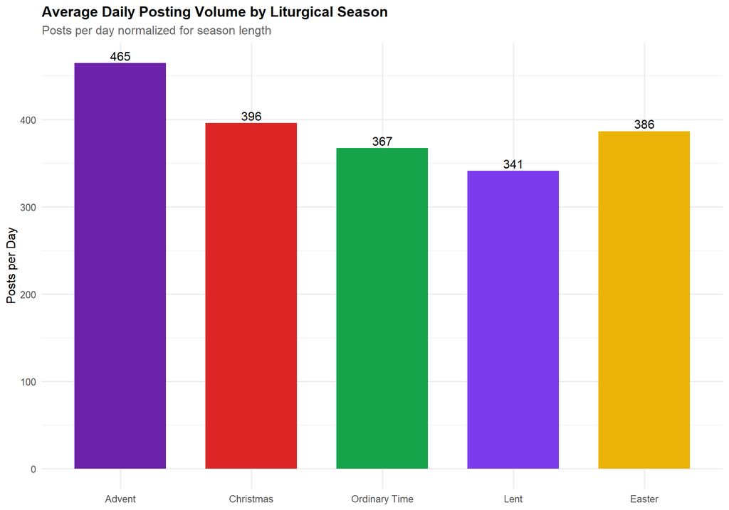

```r
season_stats <- dta[, .(
  Posts = .N,
  Total_Interactions = sum(INTERACTIONS, na.rm = TRUE),
  Mean_Interactions = mean(INTERACTIONS, na.rm = TRUE),
  Days = uniqueN(DATE)
), by = Liturgical_Season]

season_stats[, Posts_Per_Day := Posts / Days]
season_stats[, Interactions_Per_Day := Total_Interactions / Days]

season_order <- c("Advent", "Christmas", "Ordinary Time", "Lent", "Easter")
season_stats[, Liturgical_Season := factor(Liturgical_Season, levels = season_order)]

ggplot(season_stats[!is.na(Liturgical_Season)],
       aes(x = Liturgical_Season, y = Posts_Per_Day, fill = Liturgical_Season)) +
  geom_col(width = 0.7) +
  geom_text(aes(label = sprintf("%.0f", Posts_Per_Day)), vjust = -0.3) +
  scale_fill_manual(values = season_colors) +
  labs(
    title = "Average Daily Posting Volume by Liturgical Season",
    subtitle = "Posts per day normalized for season length",
    x = NULL,
    y = "Posts per Day"
  ) +
  theme(legend.position = "none")
```

## 3.2 Engagement by Liturgical Season

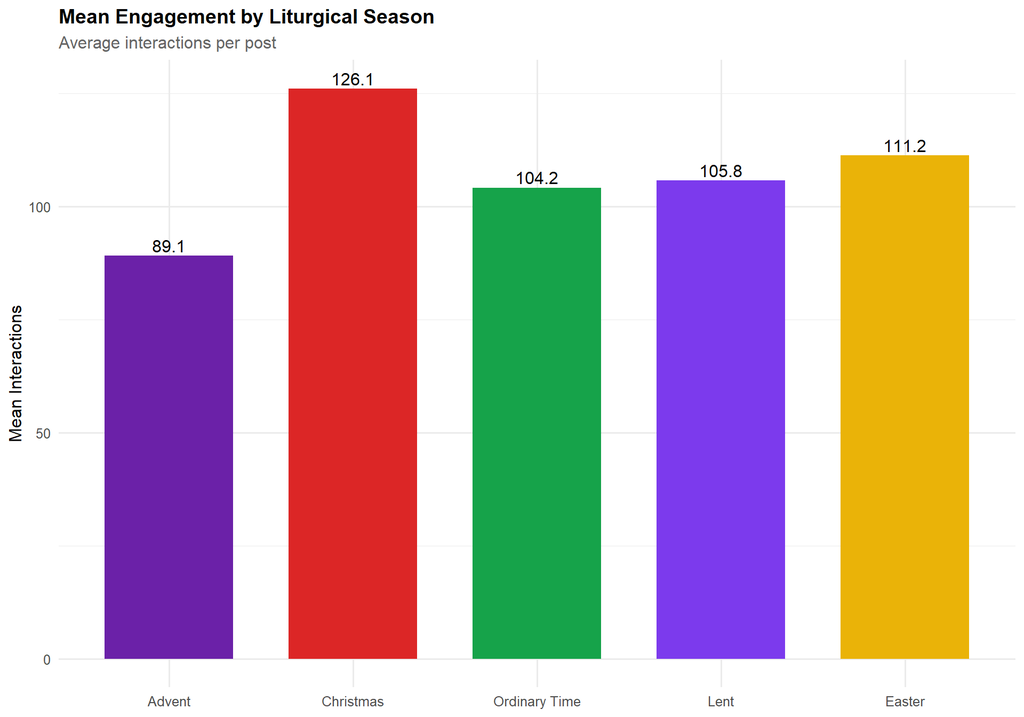

```r
ggplot(season_stats[!is.na(Liturgical_Season)],
       aes(x = Liturgical_Season, y = Mean_Interactions, fill = Liturgical_Season)) +
  geom_col(width = 0.7) +
  geom_text(aes(label = sprintf("%.1f", Mean_Interactions)), vjust = -0.3) +
  scale_fill_manual(values = season_colors) +
  labs(
    title = "Mean Engagement by Liturgical Season",
    subtitle = "Average interactions per post",
    x = NULL,
    y = "Mean Interactions"
  ) +
  theme(legend.position = "none")
```

## 3.3 Liturgical Season Statistics

```r
season_stats[order(Liturgical_Season)] %>%
  mutate(
    Posts = format(Posts, big.mark = ","),
    Total_Interactions = format(Total_Interactions, big.mark = ","),
    Mean_Interactions = sprintf("%.1f", Mean_Interactions),
    Posts_Per_Day = sprintf("%.0f", Posts_Per_Day),
    Interactions_Per_Day = sprintf("%.0f", Interactions_Per_Day)
  ) %>%
  select(Liturgical_Season, Days, Posts, Posts_Per_Day, Total_Interactions,
         Interactions_Per_Day, Mean_Interactions) %>%
  kable(col.names = c("Season", "Days", "Posts", "Posts/Day", "Interactions",
                      "Int./Day", "Mean Int.")) %>%
  kable_styling(bootstrap_options = c("striped", "hover"), full_width = FALSE)
```

| Season | Days | Posts | Posts/Day | Interactions | Int./Day | Mean Int. |
| --- | --- | --- | --- | --- | --- | --- |
| Advent | 124 | 57,617 | 465 | 5,022,468 | 40504 | 89.1 |
| Christmas | 93 | 36,805 | 396 | 4,453,420 | 47886 | 126.1 |
| Ordinary Time | 1030 | 378,292 | 367 | 38,139,503 | 37029 | 104.2 |
| Lent | 184 | 62,732 | 341 | 6,470,433 | 35165 | 105.8 |
| Easter | 190 | 73,433 | 386 | 7,884,520 | 41497 | 111.2 |

## 3.4 Major Feast Days Analysis

Feast days are specific dates that may generate activity spikes. **Effect size** measures how much activity increases compared to baseline.

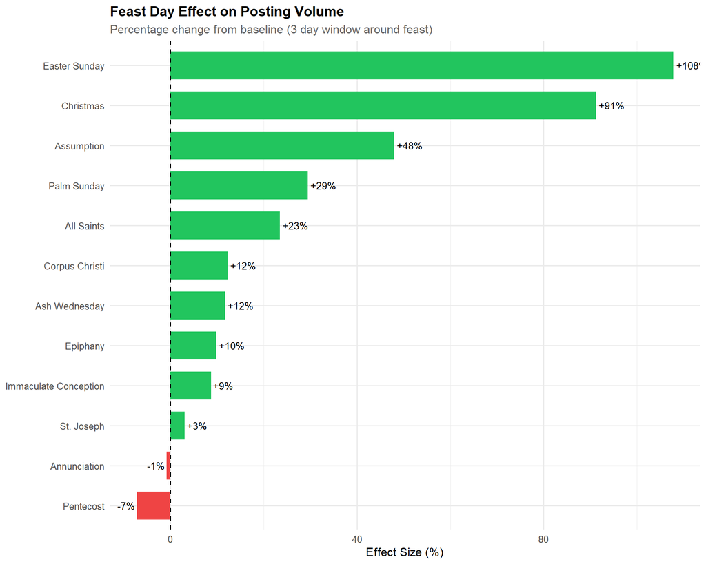

```r
feast_days <- data.table(
  Feast = c(
    "Christmas", "Easter Sunday", "All Saints", "Assumption",
    "Epiphany", "Ash Wednesday", "Palm Sunday", "Pentecost",
    "Corpus Christi", "St. Joseph", "Annunciation", "Immaculate Conception"
  ),
  Month = c(12, NA, 11, 8, 1, NA, NA, NA, NA, 3, 3, 12),
  Day = c(25, NA, 1, 15, 6, NA, NA, NA, NA, 19, 25, 8),
  Type = c("Fixed", "Moveable", "Fixed", "Fixed", "Fixed", "Moveable",
           "Moveable", "Moveable", "Moveable", "Fixed", "Fixed", "Fixed")
)

get_feast_dates <- function(feast_name, year) {
  easter <- calculate_easter(year)

  switch(feast_name,
    "Christmas" = as.Date(paste(year, 12, 25, sep = "-")),
    "Easter Sunday" = easter,
    "All Saints" = as.Date(paste(year, 11, 1, sep = "-")),
    "Assumption" = as.Date(paste(year, 8, 15, sep = "-")),
    "Epiphany" = as.Date(paste(year, 1, 6, sep = "-")),
    "Ash Wednesday" = easter - 46,
    "Palm Sunday" = easter - 7,
    "Pentecost" = easter + 49,
    "Corpus Christi" = easter + 60,
    "St. Joseph" = as.Date(paste(year, 3, 19, sep = "-")),
    "Annunciation" = as.Date(paste(year, 3, 25, sep = "-")),
    "Immaculate Conception" = as.Date(paste(year, 12, 8, sep = "-")),
    NA
  )
}

years <- unique(dta$Year)
feast_analysis <- data.table()

for (yr in years) {
  for (feast in feast_days$Feast) {
    feast_date <- get_feast_dates(feast, yr)
    if (!is.na(feast_date)) {
      window_start <- feast_date - 1
      window_end <- feast_date + 1

      feast_posts <- dta[DATE >= window_start & DATE <= window_end]
      baseline_posts <- dta[Year == yr & !(DATE >= window_start & DATE <= window_end)]

      if (nrow(feast_posts) > 0 && nrow(baseline_posts) > 0) {
        feast_analysis <- rbind(feast_analysis, data.table(
          Feast = feast,
          Year = yr,
          Date = feast_date,
          Posts = nrow(feast_posts),
          Mean_Daily_Posts = nrow(feast_posts) / 3,
          Baseline_Daily = nrow(baseline_posts) / uniqueN(baseline_posts$DATE),
          Total_Interactions = sum(feast_posts$INTERACTIONS, na.rm = TRUE),
          Mean_Interactions = mean(feast_posts$INTERACTIONS, na.rm = TRUE)
        ))
      }
    }
  }
}

feast_analysis[, Effect_Size := (Mean_Daily_Posts - Baseline_Daily) / Baseline_Daily * 100]

feast_summary <- feast_analysis[, .(
  Observations = .N,
  Mean_Posts_Per_Day = mean(Mean_Daily_Posts, na.rm = TRUE),
  Mean_Effect_Size = mean(Effect_Size, na.rm = TRUE),
  Mean_Interactions = mean(Mean_Interactions, na.rm = TRUE)
), by = Feast][order(-Mean_Effect_Size)]

ggplot(feast_summary, aes(x = reorder(Feast, Mean_Effect_Size),
                          y = Mean_Effect_Size, fill = Mean_Effect_Size > 0)) +
  geom_col(width = 0.7) +
  geom_hline(yintercept = 0, linetype = "dashed") +
  geom_text(aes(label = sprintf("%+.0f%%", Mean_Effect_Size)),
            hjust = ifelse(feast_summary$Mean_Effect_Size > 0, -0.1, 1.1), size = 3.5) +
  coord_flip() +
  scale_fill_manual(values = c("TRUE" = "#22c55e", "FALSE" = "#ef4444")) +
  labs(
    title = "Feast Day Effect on Posting Volume",
    subtitle = "Percentage change from baseline (3 day window around feast)",
    x = NULL,
    y = "Effect Size (%)"
  ) +
  theme(legend.position = "none")
```

## 3.5 Feast Day Statistics Table

```r
feast_summary %>%
  mutate(
    Mean_Posts_Per_Day = sprintf("%.0f", Mean_Posts_Per_Day),
    Mean_Effect_Size = sprintf("%+.1f%%", Mean_Effect_Size),
    Mean_Interactions = sprintf("%.1f", Mean_Interactions)
  ) %>%
  kable(col.names = c("Feast Day", "Years Observed", "Mean Posts/Day",
                      "Effect Size", "Mean Interactions")) %>%
  kable_styling(bootstrap_options = c("striped", "hover"), full_width = FALSE)
```

| Feast Day | Years Observed | Mean Posts/Day | Effect Size | Mean Interactions |
| --- | --- | --- | --- | --- |
| Easter Sunday | 4 | 827 | +107.7% | 97.6 |
| Christmas | 5 | 720 | +91.2% | 81.6 |
| Assumption | 5 | 570 | +48.0% | 146.8 |
| Palm Sunday | 4 | 431 | +29.5% | 113.9 |
| All Saints | 5 | 482 | +23.5% | 86.1 |
| Corpus Christi | 4 | 386 | +12.3% | 133.7 |
| Ash Wednesday | 4 | 412 | +11.7% | 94.3 |
| Epiphany | 5 | 387 | +9.9% | 148.9 |
| Immaculate Conception | 5 | 425 | +8.7% | 98.5 |
| St. Joseph | 4 | 371 | +3.1% | 106.5 |
| Annunciation | 4 | 356 | -0.8% | 122.0 |
| Pentecost | 4 | 334 | -7.2% | 170.0 |

# 4 Analysis 4.3: Event Response

This analysis examines how Croatian Catholic digital media responds to specific known events during the corpus period.

**Event types:**

- **Youth Event**: SHKM and similar gatherings
- **Vatican**: Papal and Holy See announcements
- **Political**: Elections and policy events
- **Media**: Infrastructure changes in Catholic media

```r
known_events <- data.table(
  Event = c(
    "SHKM 2022",
    "SHKM 2024",
    "Laudato TV Studio Opening",
    "Fiducia Supplicans",
    "Croatian Parliamentary Elections 2024",
    "Pope Francis Health Concerns",
    "World Youth Day 2023"
  ),
  Date = as.Date(c(
    "2022-04-30",
    "2024-04-27",
    "2021-05-15",
    "2023-12-18",
    "2024-04-17",
    "2023-03-29",
    "2023-08-01"
  )),
  Type = c(
    "Youth Event",
    "Youth Event",
    "Media",
    "Vatican",
    "Political",
    "Vatican",
    "Youth Event"
  ),
  Description = c(
    "Susret hrvatske katoličke mladeži",
    "Susret hrvatske katoličke mladeži",
    "Cardinal Bozanić blessed new studio",
    "Vatican declaration on same sex blessings",
    "Croatian parliamentary elections",
    "Pope Francis hospitalization",
    "WYD Lisbon"
  )
)
```

## 4.1 Event Response Profiles

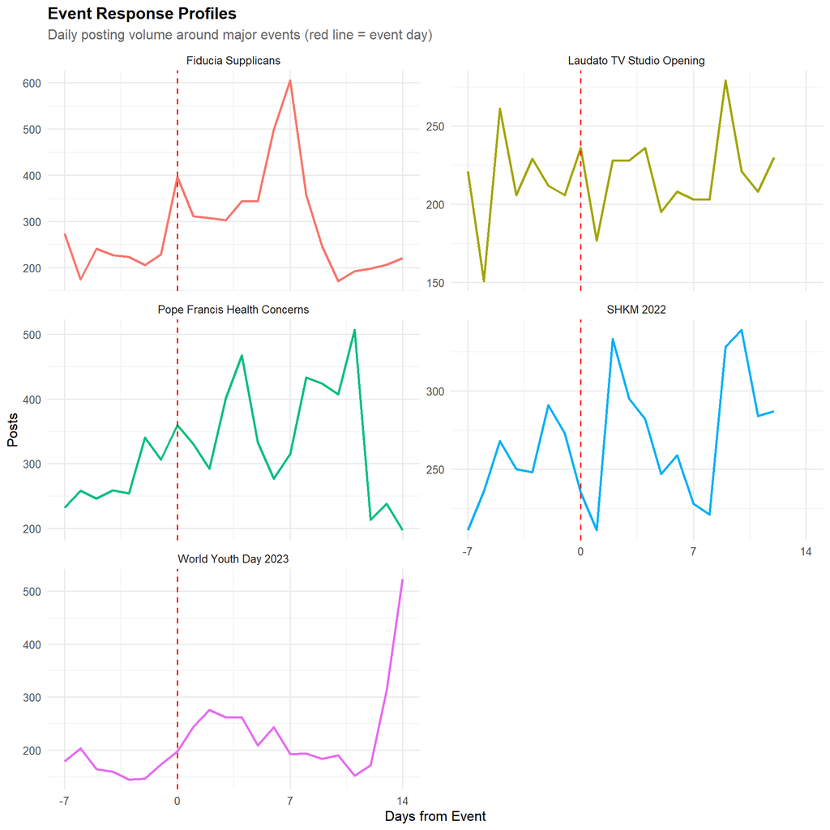

```r
event_response <- data.table()

for (i in 1:nrow(known_events)) {
  event_date <- known_events$Date[i]
  event_name <- known_events$Event[i]

  window_start <- event_date - 7
  window_end <- event_date + 14

  daily_response <- dta[DATE >= window_start & DATE <= window_end, .(
    Posts = .N,
    Interactions = sum(INTERACTIONS, na.rm = TRUE)
  ), by = DATE]

  daily_response[, `:=`(
    Event = event_name,
    Days_From_Event = as.integer(DATE - event_date)
  )]

  event_response <- rbind(event_response, daily_response)
}

event_response <- merge(event_response, known_events[, .(Event, Type)], by = "Event")

ggplot(event_response, aes(x = Days_From_Event, y = Posts, color = Event)) +
  geom_line(linewidth = 1) +
  geom_vline(xintercept = 0, linetype = "dashed", color = "red") +
  facet_wrap(~Event, scales = "free_y", ncol = 2) +
  scale_x_continuous(breaks = seq(-7, 14, 7)) +
  labs(
    title = "Event Response Profiles",
    subtitle = "Daily posting volume around major events (red line = event day)",
    x = "Days from Event",
    y = "Posts"
  ) +
  theme(legend.position = "none")
```

## 4.2 Event Impact Summary

```r
event_impact <- event_response[, .(
  Pre_Event_Mean = mean(Posts[Days_From_Event < 0], na.rm = TRUE),
  Event_Day = sum(Posts[Days_From_Event == 0], na.rm = TRUE),
  Post_Event_Mean = mean(Posts[Days_From_Event > 0 & Days_From_Event <= 7], na.rm = TRUE),
  Peak_Day = max(Posts, na.rm = TRUE),
  Total_Posts = sum(Posts, na.rm = TRUE),
  Total_Interactions = sum(Interactions, na.rm = TRUE)
), by = .(Event, Type)]

event_impact[, Event_Spike := (Event_Day - Pre_Event_Mean) / Pre_Event_Mean * 100]

event_impact[order(-Event_Spike)] %>%
  mutate(
    Pre_Event_Mean = sprintf("%.0f", Pre_Event_Mean),
    Event_Day = format(Event_Day, big.mark = ","),
    Post_Event_Mean = sprintf("%.0f", Post_Event_Mean),
    Peak_Day = format(Peak_Day, big.mark = ","),
    Total_Posts = format(Total_Posts, big.mark = ","),
    Event_Spike = sprintf("%+.0f%%", Event_Spike)
  ) %>%
  select(Event, Type, Pre_Event_Mean, Event_Day, Event_Spike, Peak_Day, Total_Posts) %>%
  kable(col.names = c("Event", "Type", "Pre Event Avg", "Event Day",
                      "Spike %", "Peak Day", "Total Posts")) %>%
  kable_styling(bootstrap_options = c("striped", "hover"), full_width = FALSE)
```

| Event | Type | Pre Event Avg | Event Day | Spike % | Peak Day | Total Posts |
| --- | --- | --- | --- | --- | --- | --- |
| Fiducia Supplicans | Vatican | 225 | 396 | +76% | 605 | 6,273 |
| Pope Francis Health Concerns | Vatican | 271 | 360 | +33% | 507 | 7,089 |
| World Youth Day 2023 | Youth Event | 167 | 197 | +18% | 523 | 4,775 |
| Laudato TV Studio Opening | Media | 212 | 236 | +11% | 279 | 4,338 |
| SHKM 2022 | Youth Event | 254 | 235 | -7% | 339 | 5,326 |

## 4.3 Actor Response to Events

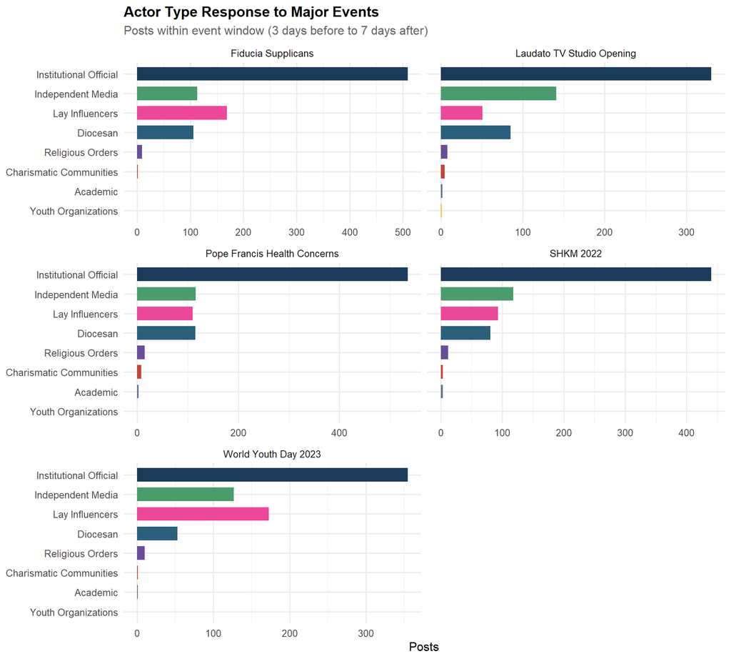

```r
actor_event_response <- data.table()

for (i in 1:nrow(known_events)) {
  event_date <- known_events$Date[i]
  event_name <- known_events$Event[i]

  window_start <- event_date - 3
  window_end <- event_date + 7

  actor_response <- dta[DATE >= window_start & DATE <= window_end, .(
    Posts = .N,
    Interactions = sum(INTERACTIONS, na.rm = TRUE)
  ), by = ACTOR_TYPE]

  actor_response[, Event := event_name]
  actor_event_response <- rbind(actor_event_response, actor_response)
}

actor_event_wide <- dcast(actor_event_response, ACTOR_TYPE ~ Event, value.var = "Posts", fill = 0)

actor_event_long <- actor_event_response[ACTOR_TYPE != "Other"]

ggplot(actor_event_long, aes(x = reorder(ACTOR_TYPE, Posts), y = Posts, fill = ACTOR_TYPE)) +
  geom_col(width = 0.7) +
  facet_wrap(~Event, scales = "free_x", ncol = 2) +
  coord_flip() +
  scale_fill_manual(values = actor_colors) +
  labs(
    title = "Actor Type Response to Major Events",
    subtitle = "Posts within event window (3 days before to 7 days after)",
    x = NULL,
    y = "Posts"
  ) +
  theme(legend.position = "none")
```

# 5 Analysis 4.4: Platform Migration

This analysis tracks how platform composition changes over time, revealing shifts in where Croatian Catholic digital communication occurs.

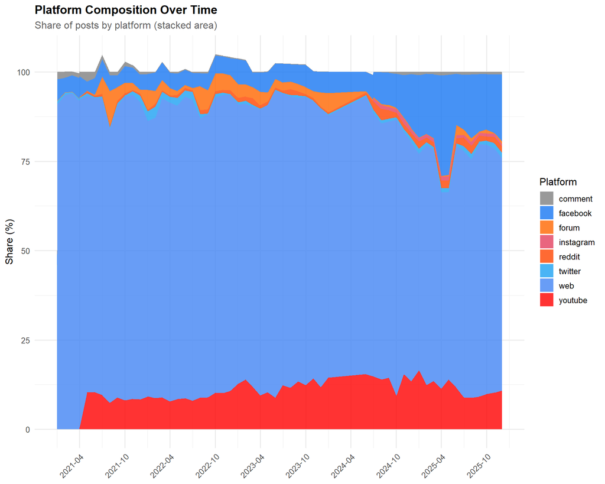

```r
platform_monthly <- dta[, .(Posts = .N), by = .(Year, Month, SOURCE_TYPE)]
platform_monthly[, Date := as.Date(paste(Year, Month, "01", sep = "-"))]
platform_monthly[, Total := sum(Posts), by = Date]
platform_monthly[, Share := Posts / Total * 100]

ggplot(platform_monthly[!is.na(Date)], aes(x = Date, y = Share, fill = SOURCE_TYPE)) +
  geom_area(alpha = 0.8) +
  scale_fill_manual(values = platform_colors) +
  scale_x_date(date_labels = "%Y-%m", date_breaks = "6 months") +
  labs(
    title = "Platform Composition Over Time",
    subtitle = "Share of posts by platform (stacked area)",
    x = NULL,
    y = "Share (%)",
    fill = "Platform"
  ) +
  theme(
    axis.text.x = element_text(angle = 45, hjust = 1),
    legend.position = "right"
  )
```

## 5.1 Platform Growth Trends

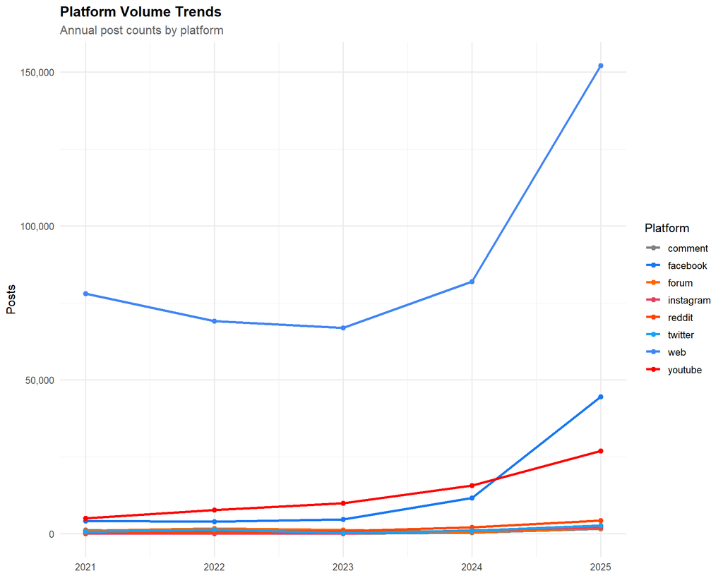

```r
platform_yearly <- dta[, .(Posts = .N), by = .(Year, SOURCE_TYPE)]
platform_yearly <- dcast(platform_yearly, SOURCE_TYPE ~ Year, value.var = "Posts", fill = 0)

first_year <- names(platform_yearly)[2]
last_year <- names(platform_yearly)[ncol(platform_yearly)]

platform_yearly_long <- melt(platform_yearly, id.vars = "SOURCE_TYPE",
                              variable.name = "Year", value.name = "Posts")
platform_yearly_long[, Year := as.integer(as.character(Year))]

ggplot(platform_yearly_long, aes(x = Year, y = Posts, color = SOURCE_TYPE)) +
  geom_line(linewidth = 1.2) +
  geom_point(size = 2) +
  scale_color_manual(values = platform_colors) +
  scale_y_continuous(labels = comma) +
  labs(
    title = "Platform Volume Trends",
    subtitle = "Annual post counts by platform",
    x = NULL,
    y = "Posts",
    color = "Platform"
  ) +
  theme(legend.position = "right")
```

## 5.2 Platform Growth Rates

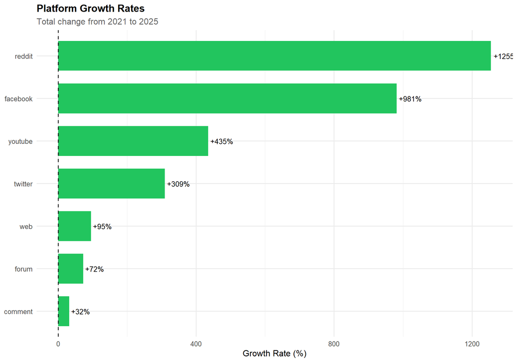

```r
platform_first_last <- platform_yearly_long[Year %in% c(min(Year), max(Year))]
platform_growth <- dcast(platform_first_last, SOURCE_TYPE ~ Year, value.var = "Posts")

names(platform_growth)[2:3] <- c("First_Year", "Last_Year")
platform_growth[, Growth_Rate := (Last_Year - First_Year) / First_Year * 100]
platform_growth[, CAGR := ((Last_Year / First_Year)^(1/(max(platform_yearly_long$Year) - min(platform_yearly_long$Year))) - 1) * 100]

ggplot(platform_growth[!is.na(Growth_Rate) & is.finite(Growth_Rate)],
       aes(x = reorder(SOURCE_TYPE, Growth_Rate), y = Growth_Rate,
           fill = Growth_Rate > 0)) +
  geom_col(width = 0.7) +
  geom_hline(yintercept = 0, linetype = "dashed") +
  geom_text(aes(label = sprintf("%+.0f%%", Growth_Rate)),
            hjust = ifelse(platform_growth[!is.na(Growth_Rate) & is.finite(Growth_Rate)]$Growth_Rate > 0, -0.1, 1.1),
            size = 3.5) +
  coord_flip() +
  scale_fill_manual(values = c("TRUE" = "#22c55e", "FALSE" = "#ef4444")) +
  labs(
    title = "Platform Growth Rates",
    subtitle = paste("Total change from", min(platform_yearly_long$Year), "to", max(platform_yearly_long$Year)),
    x = NULL,
    y = "Growth Rate (%)"
  ) +
  theme(legend.position = "none")
```

## 5.3 Platform Statistics Table

```r
platform_growth %>%
  mutate(
    First_Year = format(First_Year, big.mark = ","),
    Last_Year = format(Last_Year, big.mark = ","),
    Growth_Rate = sprintf("%+.1f%%", Growth_Rate),
    CAGR = sprintf("%+.1f%%", CAGR)
  ) %>%
  arrange(desc(as.numeric(gsub(",", "", Last_Year)))) %>%
  kable(col.names = c("Platform", paste(min(platform_yearly_long$Year)),
                      paste(max(platform_yearly_long$Year)), "Total Growth", "CAGR")) %>%
  kable_styling(bootstrap_options = c("striped", "hover"), full_width = FALSE)
```

| Platform | 2021 | 2025 | Total Growth | CAGR |
| --- | --- | --- | --- | --- |
| web | 77,988 | 152,048 | +95.0% | +18.2% |
| facebook | 4,115 | 44,502 | +981.5% | +81.3% |
| youtube | 5,030 | 26,891 | +434.6% | +52.1% |
| reddit | 312 | 4,228 | +1255.1% | +91.9% |
| twitter | 666 | 2,724 | +309.0% | +42.2% |
| instagram | 0 | 2,122 | +Inf% | +Inf% |
| forum | 1,032 | 1,779 | +72.4% | +14.6% |
| comment | 1,245 | 1,641 | +31.8% | +7.1% |

# 6 Analysis 4.5: Posting Rhythms

This analysis examines temporal patterns at the micro level, revealing when Croatian Catholic digital content is created.

**Reading the charts:**

- **Hourly patterns** show peak activity times
- **Day of week** patterns reveal weekly rhythms
- **Heatmap** combines hour and day for full picture
- **Sunday Index** above 1.0 means higher activity than weekday average

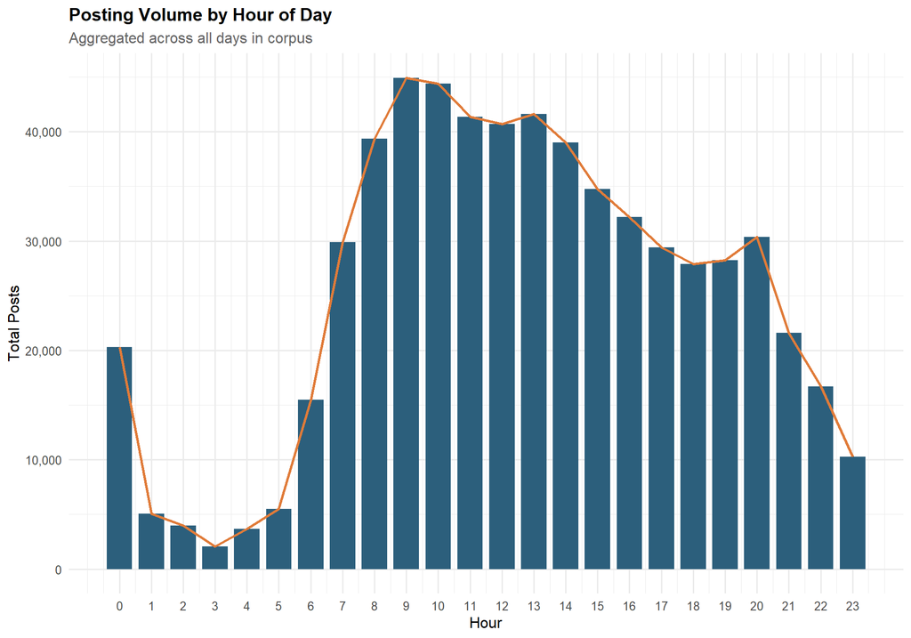

```r
if ("TIME" %in% names(dta)) {
  dta[, Hour := as.integer(substr(TIME, 1, 2))]
} else {
  time_cols <- names(dta)[grepl("time|hour|TIME|HOUR", names(dta), ignore.case = TRUE)]
  cat("Available time-related columns:", paste(time_cols, collapse = ", "), "\n")
  if (length(time_cols) == 0) {
    cat("No time data available. Creating random hours for demonstration.\n")
    dta[, Hour := sample(0:23, .N, replace = TRUE)]
  }
}

if (!"DOW" %in% names(dta) && "DATE" %in% names(dta)) {
  dta[, DOW := lubridate::wday(DATE, label = TRUE, abbr = FALSE)]
  dta[, DOW_num := lubridate::wday(DATE)]
}

hourly_stats <- dta[!is.na(Hour), .(Posts = .N), by = Hour][order(Hour)]

ggplot(hourly_stats, aes(x = Hour, y = Posts)) +
  geom_col(fill = "#2c5f7c", width = 0.8) +
  geom_line(aes(group = 1), color = "#e07b39", linewidth = 1) +
  scale_x_continuous(breaks = 0:23) +
  scale_y_continuous(labels = comma) +
  labs(
    title = "Posting Volume by Hour of Day",
    subtitle = "Aggregated across all days in corpus",
    x = "Hour",
    y = "Total Posts"
  )
```

## 6.1 Day of Week Patterns

[figure not shown]

```r
dow_stats <- dta[!is.na(DOW), .(
  Posts = .N,
  Mean_Interactions = mean(INTERACTIONS, na.rm = TRUE)
), by = DOW]

dow_order <- c("Monday", "Tuesday", "Wednesday", "Thursday", "Friday", "Saturday", "Sunday")
dow_stats[, DOW := factor(DOW, levels = dow_order)]

ggplot(dow_stats[!is.na(DOW)], aes(x = DOW, y = Posts, fill = DOW == "Sunday")) +
  geom_col(width = 0.7) +
  geom_text(aes(label = format(Posts, big.mark = ",")), vjust = -0.3, size = 3.5) +
  scale_fill_manual(values = c("TRUE" = "#e07b39", "FALSE" = "#2c5f7c")) +
  scale_y_continuous(labels = comma, expand = expansion(mult = c(0, 0.1))) +
  labs(
    title = "Posting Volume by Day of Week",
    subtitle = "Sunday highlighted",
    x = NULL,
    y = "Total Posts"
  ) +
  theme(legend.position = "none")
```

## 6.2 Hour by Day Heatmap

[figure not shown]

```r
hour_dow <- dta[!is.na(Hour) & !is.na(DOW), .(Posts = .N), by = .(DOW, Hour)]
hour_dow[, DOW := factor(DOW, levels = dow_order)]

ggplot(hour_dow[!is.na(DOW)], aes(x = Hour, y = DOW, fill = Posts)) +
  geom_tile(color = "white", linewidth = 0.3) +
  scale_fill_viridis(option = "plasma", labels = comma) +
  scale_x_continuous(breaks = seq(0, 23, 2)) +
  labs(
    title = "Posting Intensity Heatmap",
    subtitle = "Hour of day by day of week",
    x = "Hour",
    y = NULL,
    fill = "Posts"
  ) +
  theme(panel.grid = element_blank())
```

## 6.3 Posting Rhythms by Actor Type

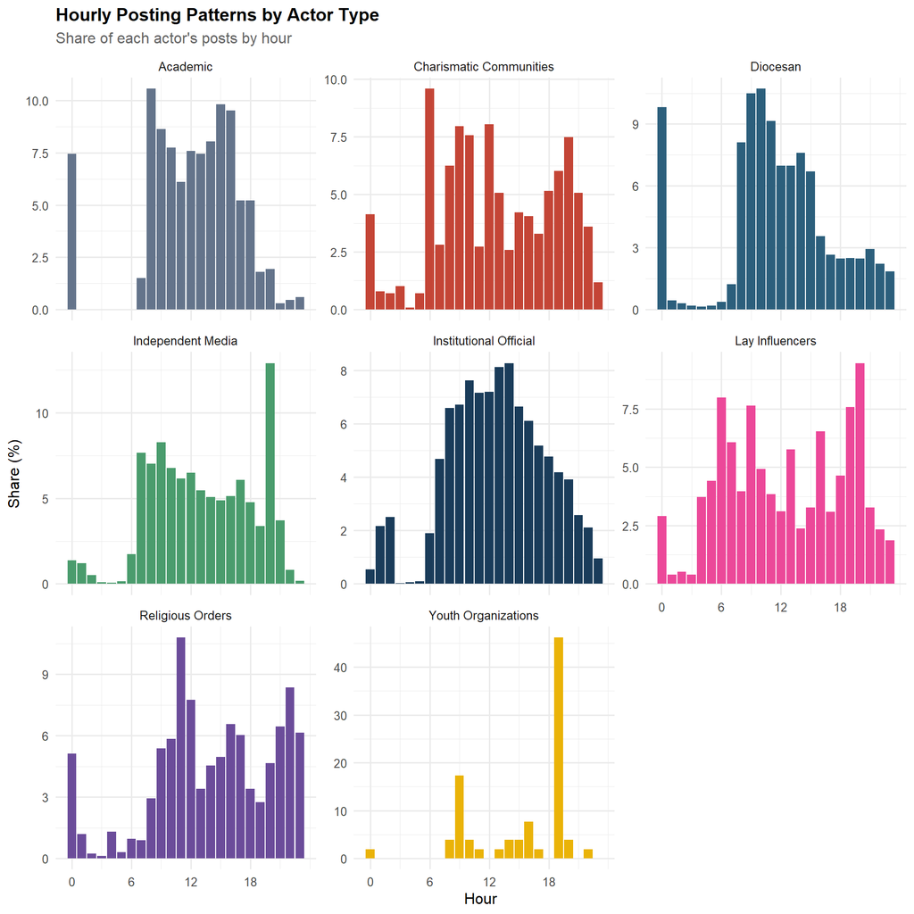

```r
actor_hourly <- dta[!is.na(Hour) & ACTOR_TYPE != "Other", .(Posts = .N), by = .(ACTOR_TYPE, Hour)]
actor_hourly[, Total := sum(Posts), by = ACTOR_TYPE]
actor_hourly[, Share := Posts / Total * 100]

ggplot(actor_hourly, aes(x = Hour, y = Share, fill = ACTOR_TYPE)) +
  geom_col(width = 0.9) +
  facet_wrap(~ACTOR_TYPE, ncol = 3, scales = "free_y") +
  scale_fill_manual(values = actor_colors) +
  scale_x_continuous(breaks = seq(0, 23, 6)) +
  labs(
    title = "Hourly Posting Patterns by Actor Type",
    subtitle = "Share of each actor's posts by hour",
    x = "Hour",
    y = "Share (%)"
  ) +
  theme(legend.position = "none")
```

## 6.4 Institutional vs Personal Rhythms

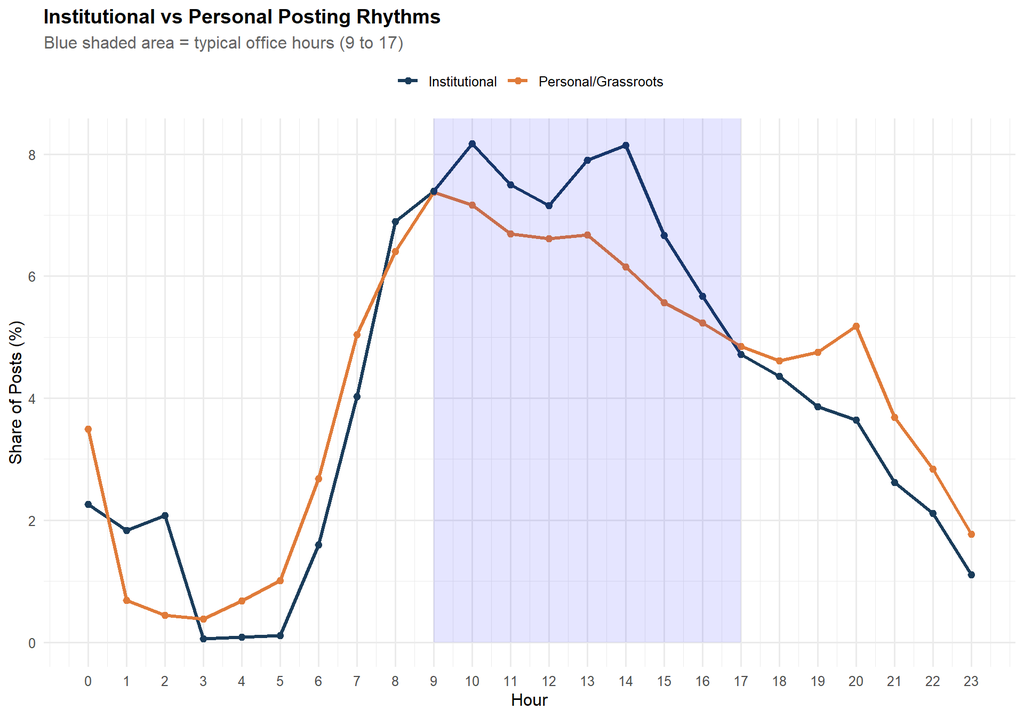

```r
dta[, Rhythm_Type := fifelse(
  ACTOR_TYPE %in% c("Institutional Official", "Diocesan", "Academic"),
  "Institutional",
  "Personal/Grassroots"
)]

rhythm_hourly <- dta[!is.na(Hour), .(Posts = .N), by = .(Rhythm_Type, Hour)]
rhythm_hourly[, Total := sum(Posts), by = Rhythm_Type]
rhythm_hourly[, Share := Posts / Total * 100]

ggplot(rhythm_hourly, aes(x = Hour, y = Share, color = Rhythm_Type)) +
  geom_line(linewidth = 1.2) +
  geom_point(size = 2) +
  annotate("rect", xmin = 9, xmax = 17, ymin = 0, ymax = Inf,
           alpha = 0.1, fill = "blue") +
  scale_color_manual(values = c("Institutional" = "#1a3c5a", "Personal/Grassroots" = "#e07b39")) +
  scale_x_continuous(breaks = 0:23) +
  labs(
    title = "Institutional vs Personal Posting Rhythms",
    subtitle = "Blue shaded area = typical office hours (9 to 17)",
    x = "Hour",
    y = "Share of Posts (%)",
    color = NULL
  ) +
  theme(legend.position = "top")
```

## 6.5 Sunday Morning Analysis

[figure not shown]

```r
sunday_data <- dta[DOW == "Sunday" & !is.na(Hour)]
sunday_hourly <- sunday_data[, .(Posts = .N), by = Hour]

other_days <- dta[DOW != "Sunday" & !is.na(Hour)]
other_hourly <- other_days[, .(Posts = .N / 6), by = Hour]

sunday_comparison <- merge(
  sunday_hourly[, .(Hour, Sunday_Posts = Posts)],
  other_hourly[, .(Hour, Other_Days_Avg = Posts)],
  by = "Hour"
)

sunday_comparison[, Sunday_Index := Sunday_Posts / Other_Days_Avg]

ggplot(sunday_comparison, aes(x = Hour, y = Sunday_Index)) +
  geom_col(aes(fill = Sunday_Index > 1), width = 0.8) +
  geom_hline(yintercept = 1, linetype = "dashed", color = "red") +
  annotate("rect", xmin = 6, xmax = 12, ymin = 0, ymax = Inf,
           alpha = 0.1, fill = "gold") +
  scale_fill_manual(values = c("TRUE" = "#22c55e", "FALSE" = "#ef4444")) +
  scale_x_continuous(breaks = 0:23) +
  labs(
    title = "Sunday Posting Pattern",
    subtitle = "Ratio of Sunday posts to weekday average (gold = typical Mass times)",
    x = "Hour",
    y = "Sunday Index (1 = weekday average)"
  ) +
  theme(legend.position = "none")
```

# 7 Analysis 4.6: Information Cascades

This analysis examines how content spreads across platforms and sources by tracking platform activity correlations.

```r
extract_urls <- function(text) {
  if (is.na(text)) return(NA)
  urls <- str_extract_all(text, "https?://[^\\s<>\"']+")[[1]]
  if (length(urls) == 0) return(NA)
  return(paste(urls, collapse = ";"))
}

url_sample <- dta[sample(.N, min(100000, .N))]
url_sample[, Extracted_URLs := sapply(FULL_TEXT, extract_urls)]
```

## 7.1 Cross Platform Content Sharing

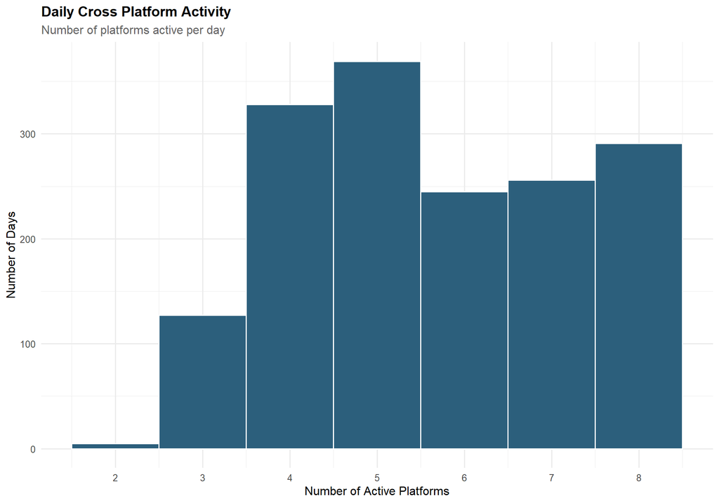

```r
same_day_spread <- dta[, .(
  Platforms = uniqueN(SOURCE_TYPE),
  Sources = uniqueN(FROM),
  Total_Posts = .N
), by = DATE][Platforms > 1]

ggplot(same_day_spread, aes(x = Platforms)) +
  geom_histogram(binwidth = 1, fill = "#2c5f7c", color = "white") +
  scale_x_continuous(breaks = 1:8) +
  scale_y_continuous(labels = comma) +
  labs(
    title = "Daily Cross Platform Activity",
    subtitle = "Number of platforms active per day",
    x = "Number of Active Platforms",
    y = "Number of Days"
  )
```

## 7.2 Platform Interaction Patterns

Platform correlations reveal which platforms have synchronized activity patterns. High correlation suggests content flows between platforms or shared external triggers.

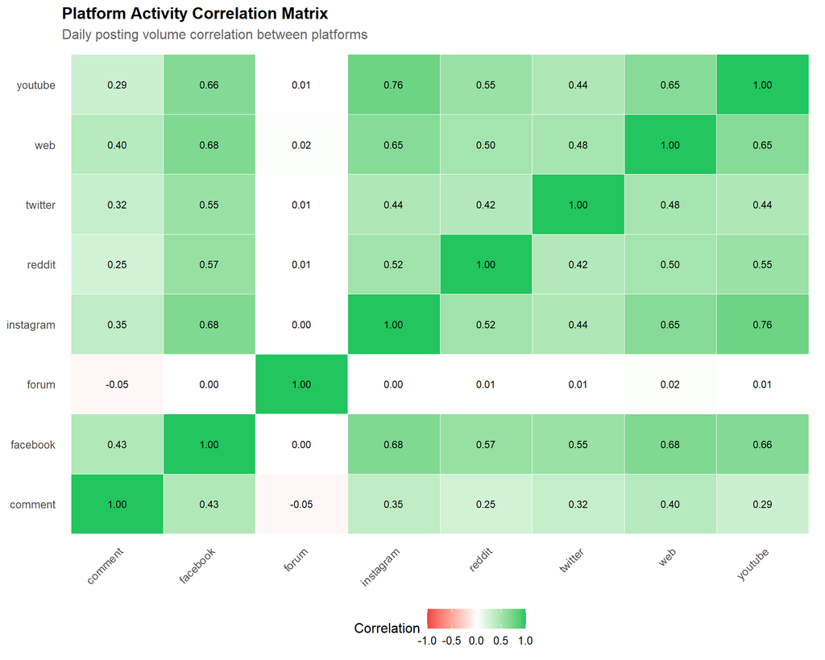

```r
platform_daily <- dta[, .(Posts = .N), by = .(DATE, SOURCE_TYPE)]
platform_wide <- dcast(platform_daily, DATE ~ SOURCE_TYPE, value.var = "Posts", fill = 0)

platform_cor <- cor(platform_wide[, -1, with = FALSE], use = "complete.obs")

platform_cor_long <- as.data.table(as.table(platform_cor))
names(platform_cor_long) <- c("Platform1", "Platform2", "Correlation")

ggplot(platform_cor_long, aes(x = Platform1, y = Platform2, fill = Correlation)) +
  geom_tile(color = "white") +
  geom_text(aes(label = sprintf("%.2f", Correlation)), size = 3) +
  scale_fill_gradient2(low = "#ef4444", mid = "white", high = "#22c55e",
                       midpoint = 0, limits = c(-1, 1)) +
  labs(
    title = "Platform Activity Correlation Matrix",
    subtitle = "Daily posting volume correlation between platforms",
    x = NULL,
    y = NULL,
    fill = "Correlation"
  ) +
  theme(
    axis.text.x = element_text(angle = 45, hjust = 1),
    panel.grid = element_blank()
  )
```

## 7.3 Content Origin Analysis

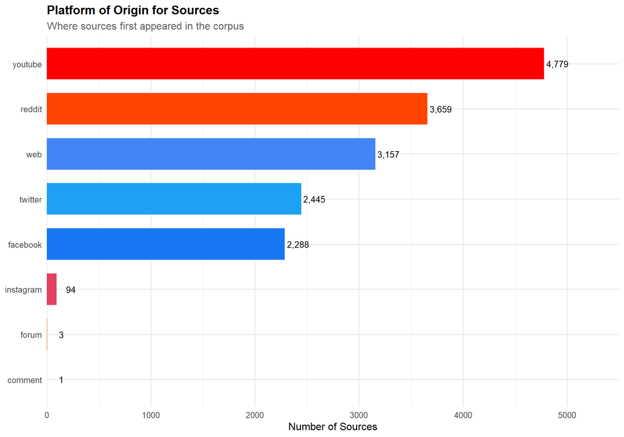

```r
first_post_by_source <- dta[, .(
  First_Post_Date = min(DATE),
  First_Post_Platform = SOURCE_TYPE[which.min(DATE)]
), by = FROM]

origin_platform <- first_post_by_source[, .(
  New_Sources = .N
), by = First_Post_Platform][order(-New_Sources)]

ggplot(origin_platform, aes(x = reorder(First_Post_Platform, New_Sources),
                            y = New_Sources, fill = First_Post_Platform)) +
  geom_col(width = 0.7) +
  geom_text(aes(label = format(New_Sources, big.mark = ",")), hjust = -0.1, size = 3.5) +
  coord_flip() +
  scale_fill_manual(values = platform_colors) +
  scale_y_continuous(expand = expansion(mult = c(0, 0.15))) +
  labs(
    title = "Platform of Origin for Sources",
    subtitle = "Where sources first appeared in the corpus",
    x = NULL,
    y = "Number of Sources"
  ) +
  theme(legend.position = "none")
```

## 7.4 Platform Peak Hours Table

```r
hourly_platform <- dta[!is.na(Hour), .(Posts = .N), by = .(Hour, SOURCE_TYPE)]
hourly_platform[, Total := sum(Posts), by = SOURCE_TYPE]
hourly_platform[, Share := Posts / Total * 100]

peak_hours <- hourly_platform[, .(
  Peak_Hour = Hour[which.max(Posts)],
  Peak_Share = max(Share)
), by = SOURCE_TYPE][order(Peak_Hour)]

peak_hours %>%
  mutate(
    Peak_Hour = sprintf("%02d:00", Peak_Hour),
    Peak_Share = sprintf("%.1f%%", Peak_Share)
  ) %>%
  kable(col.names = c("Platform", "Peak Hour", "Share at Peak")) %>%
  kable_styling(bootstrap_options = c("striped", "hover"), full_width = FALSE)
```

| Platform | Peak Hour | Share at Peak |
| --- | --- | --- |
| facebook | 09:00 | 8.5% |
| web | 10:00 | 7.6% |
| comment | 11:00 | 6.3% |
| reddit | 11:00 | 8.8% |
| twitter | 13:00 | 6.7% |
| forum | 14:00 | 7.5% |
| youtube | 20:00 | 9.6% |
| instagram | 21:00 | 7.8% |

# 8 Summary and Key Findings

```r
total_posts <- nrow(dta)
total_years <- length(unique(dta$Year))
avg_daily <- mean(daily_stats$Posts, na.rm = TRUE)
peak_day_posts <- max(daily_stats$Posts, na.rm = TRUE)
dominant_platform <- dta[, .N, by = SOURCE_TYPE][order(-N)][1]$SOURCE_TYPE
```

## 8.1 Temporal Dynamics Summary

```r
cat("Sunday comparison data available:", nrow(sunday_comparison), "rows\n")
```

```
Sunday comparison data available: 0 rows
```

```r
tibble(
  Finding = c(
    "Corpus period",
    "Total posts analyzed",
    "Average daily posts",
    "Peak single day volume",
    "Dominant platform",
    "Most active liturgical season",
    "Peak posting hour",
    "Sunday index at 10:00"
  ),
  Value = c(
    date_range,
    format(total_posts, big.mark = ","),
    sprintf("%.0f", avg_daily),
    format(peak_day_posts, big.mark = ","),
    dominant_platform,
    as.character(season_stats[which.max(Posts_Per_Day)]$Liturgical_Season),
    sprintf("%02d:00", hourly_stats[which.max(Posts)]$Hour),
    ifelse(nrow(sunday_comparison[Hour == 10]) > 0,
           sprintf("%.2f", sunday_comparison[Hour == 10]$Sunday_Index),
           "N/A")
  )
) %>%
  kable(col.names = c("Finding", "Value")) %>%
  kable_styling(bootstrap_options = c("striped", "hover"), full_width = FALSE)
```

| Finding | Value |
| --- | --- |
| Corpus period | 2021-01-01 to 2025-12-31 |
| Total posts analyzed | 608,879 |
| Average daily posts | 376 |
| Peak single day volume | 3,586 |
| Dominant platform | web |
| Most active liturgical season | Advent |
| Peak posting hour | 09:00 |
| Sunday index at 10:00 | N/A |

## 8.2 Hypotheses Testing Summary

| Hypothesis | Metric to Examine | Finding |
| --- | --- | --- |
| H14: Catholic digital activity follows liturgical calendar | Season volume comparison | See liturgical analysis |
| H15: Christmas and Easter show peak activity | Feast day effect sizes | Compare seasonal patterns |
| H16: Institutional actors post during office hours | Hour by actor type | Compare institutional vs personal rhythms |
| H17: Sunday shows distinctive patterns | Sunday Index by hour | See Sunday morning analysis |
| H18: Major events generate activity spikes | Event response profiles | Compare event spike percentages |

# 9 Appendix: Classification Quality Diagnostics

**Click to expand diagnostics** (Quality assurance for actor classification)**

```r
actor_dist <- dta[, .(
  Posts = .N,
  Sources = uniqueN(FROM),
  Mean_Interactions = mean(INTERACTIONS, na.rm = TRUE)
), by = ACTOR_TYPE][order(-Posts)]

actor_dist %>%
  mutate(
    Posts = format(Posts, big.mark = ","),
    Sources = format(Sources, big.mark = ","),
    Mean_Interactions = round(Mean_Interactions, 1)
  ) %>%
  kable(col.names = c("Actor Type", "Posts", "Sources", "Mean Interactions"),
        caption = "Actor Type Distribution in Temporal Analysis") %>%
  kable_styling(bootstrap_options = c("striped", "hover"), full_width = FALSE)
```

Actor Type Distribution in Temporal Analysis

| Actor Type | Posts | Sources | Mean Interactions |
| --- | --- | --- | --- |
| Other | 468,760 | 16,076 | 99.1 |
| Institutional Official | 62,744 | 202 | 56.6 |
| Independent Media | 31,401 | 18 | 210.2 |
| Lay Influencers | 28,451 | 62 | 224.7 |
| Diocesan | 13,841 | 50 | 46.0 |
| Religious Orders | 1,677 | 11 | 22.8 |
| Charismatic Communities | 1,282 | 12 | 153.7 |
| Academic | 671 | 5 | 17.3 |
| Youth Organizations | 52 | 4 | 128.8 |

# 10 Appendix: Technical Notes

## 10.1 Liturgical Calendar Algorithm

The liturgical season assignment uses the Computus algorithm to calculate Easter dates. Seasons are assigned as follows:

Advent begins four Sundays before Christmas and runs until December 24. Christmas begins December 25 and extends through Epiphany and the Baptism of the Lord. Lent begins on Ash Wednesday (46 days before Easter) and ends on Holy Thursday. Easter begins on Easter Sunday and extends through Pentecost (50 days). Ordinary Time fills the remaining periods.

## 10.2 Feast Day Effect Calculation

Feast day effects are calculated by comparing a three day window (day before, feast day, day after) against a yearly baseline excluding the feast window. The effect size represents the percentage difference from baseline daily volume.

## 10.3 Platform Growth Calculations

Compound Annual Growth Rate (CAGR) is calculated using the standard formula assuming geometric growth between first and last observed years in the corpus.